# Data Processing

2025-12-17

# 1. data processing

```r
# Example: load a dataset included in the package

# ring measurement
dt.samples <- fread(system.file("extdata", "dt.samples.csv", package = "growthTrendR"))

# formatting the users' data conformed to CFS-TRenD data structure
dt.samples_trt <- CFS_format(data = list(dt.samples, 39:68), usage = 1, out.csv = NULL)
```

```
#> [1] "you have filled all the mandatory information"
#> [1] "you have filled all the un-mandatory information"
```

```r
class(dt.samples_trt)
```

```
#> [1] "cfs_format"
```

```r
# save it to extdata for further use
# saveRDS(dt.samples_trt, "inst/extdata/dt.samples_trt.rds")
```

### **arguments of CFS_format() function:**

**data**

All information should be provided in a single file in wide format, with metadata first, followed by the ring-width measurements (in mm).

The column names for the ring-width measurements can follow two formats to indicate the year of measurement: Directly as the year (e.g., 1980) or Prefixed with a character (e.g., X1980).

It is highly recommended that the ring-width measurement columns are ordered by year and consecutive in the dataset, as the column indices will be used as input for the function CFS_format().

data = list (dt.samples, 39:68)), the second item refers to the column indices

**usage**

If users intend to submit their data to the CFS-TRenD online repository, set usage = 1 in the function. This will enable the function to format the data structure and perform detailed checks, including column names, geographic coordinates, species, and other requirements to conform to the CFS-TRenD collection standards.

Otherwise, use usage = 2 to perform a reduced checking procedure, which still builds the CFS-TRenD structure but skips some of the detailed validations.

**out.csv**

if user wants to export the processed tables in csv format, specify the folder here. the default is NULL.

**Note:** Running the function CFS_format() is the first and mandatory step before using any other functions in the growthTrendR package. The data provided in this tutorial is already prepared to run the vignette; in practice, users may need to add or modify their own data based on the messages generated by the function.

# 2. generate data report:

The data report provides an overview of the tree ring data’s quality and characteristics at four levels: project, project-species, project-species-site, and project-species-radii, including the quality assessment at site and radii levels with the default parameters. More details on quality assessment will be presented next section.

```r
outfile_data <- tempfile(fileext = ".html")
generate_report(robj = dt.samples_trt, qa.label_data = "demo-samples ", data_report.reports_sel = c(1,2,3,4), qa.min_nseries = 50, output_file = outfile_data)
```

#### **arguments of the generate_report() function:**

**robj**

The input for the data report is the output of the CFS_format() function, which assigns the class “cfs_format” to the resulting object.

**qa.label_data**

A short description of the input dataset. This text will appear in the report as the data source for the generated figures.

**output_file**

This argument allows users to export the HTML-formatted report to a specified location by providing a folder and filename (e.g., “path/to/report.html”). If left as NULL (default), the report will not be saved to disk and will instead open directly in the browser for viewing.

# Data summary report

2025-12-17

This report provides an overview of the tree ring data’s quality and characteristics at four levels:

```
1. project: Data Completeness: Assessment of missing or incomplete data of the whole data;
2. project-species: Data Summary: Summary statistics and descriptions;
3. project-species-site: data summary tables and series graphing;
4. project-species-site-radii: Correlation Analysis and quality assessment.
```

project name: **Douglas-fir retrospective monitoring**

selected reports: **1, 2, 3, 4**

### data completeness

This table presents the completeness of each variable of the whole dataset as a percentage. A value of 0 indicates no effective data. Please carefully verify that all required data has been included in the submission.

| var | pct |
| --- | --- |
| tr1_submission_id | 100 |
| tr1_project_name | 100 |
| tr1_description | 100 |
| tr1_year_range | 100 |
| tr1_reference | 100 |
| tr1_open_data | 100 |
| tr1_contact1 | 100 |
| tr1_contact2 | 100 |
| tr2_site_id | 100 |
| tr2_latitude | 100 |
| tr2_longitude | 100 |
| tr2_datasource | 100 |
| tr2_investigators | 100 |

| var | pct |
| --- | --- |
| tr2_province_iso_code | 100 |
| tr3_tree_id | 100 |
| tr3_species | 100 |
| tr4_meas_no | 0 |
| tr4_meas_date | 100 |
| tr4_status | 100 |
| tr4_dbh_cm | 100 |
| tr4_ht_tot_m | 100 |
| tr5_sample_id | 100 |
| tr5_sample_type | 100 |
| tr5_sample_ht_m | 0 |
| tr5_sample_diameter_cm | 0 |

| var | pct |
| --- | --- |
| tr6_radius_id | 100.0 |
| tr6_cofecha_id | 0.0 |
| tr6_ring_meas_method | 100.0 |
| tr6_crossdating_visual | 100.0 |
| tr6_crossdating_validation | 100.0 |
| tr6_age_corrected | 0.0 |
| tr6_bark_thickness_mm | 0.0 |
| tr6_radius_inside_cm | 100.0 |
| tr6_dtc_measured_mm | 100.0 |
| tr6_dtc_estimated_mm | 22.2 |
| tr6_rw_ystart | 100.0 |
| tr6_rw_yend | 100.0 |
| tr6_comments | 0.0 |

### Data Summary (Species)

This section presents key summary statistics, including spatial and temporal ranges, summary of ring width measurements, series length, etc., categorized by species.

In this dataset, there’s 1 species: PSEUMEN

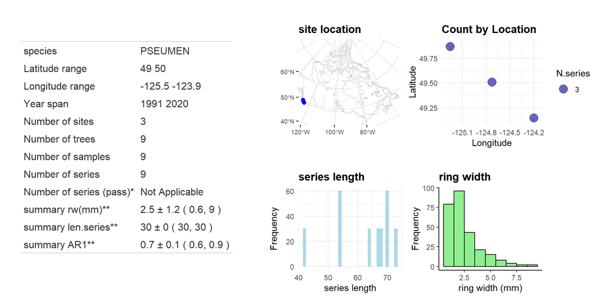

*Number of series that passed the test of CFS_qa() on differentiated series

**The values refer to mean ± sd (min, max)

### site-level data summary

This section presents site-level data summaries, including a figure showing ring width measurements over time and a table with key statistics.

##### PSEUMEN on ring width measurement

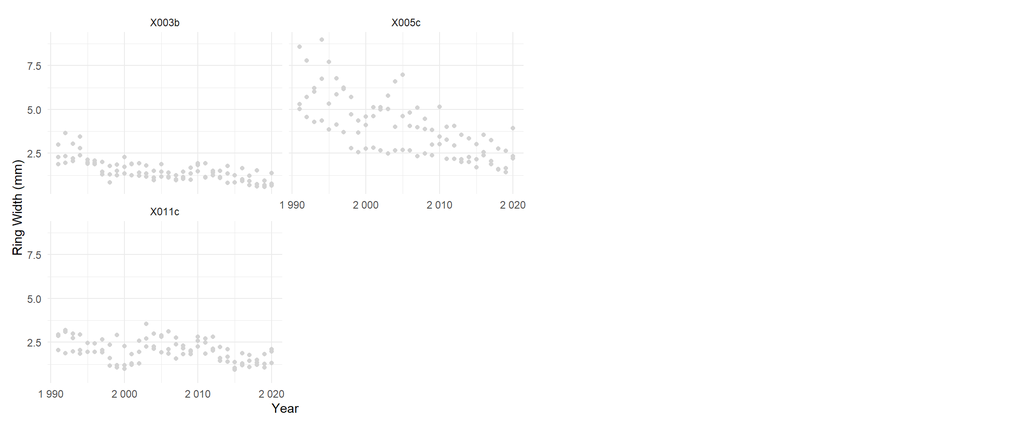

PSEUMEN

| site_id | lon | lat | Nb. trees | len.series** | rw(mm)** |
| --- | --- | --- | --- | --- | --- |
| X003b | -123.9337 | 48.96656 | 3 | 30 ± 0 ( 30, 30 ) | 1.5 ± 0.2 ( 0.6, 3.7 ) |
| X005c | -124.7485 | 49.42990 | 3 | 30 ± 0 ( 30, 30 ) | 4 ± 0.8 ( 1.4, 9 ) |
| X011c | -125.5210 | 50.04691 | 3 | 30 ± 0 ( 30, 30 ) | 2 ± 0.3 ( 0.9, 3.5 ) |

*ratio between median of rw of the site and median of rw of its 10 nearest neighbors.  
**The values refer to mean ± sd (min, max)

### Correlation and quality assessment code

PSEUMEN

| site_id | radius_id | year from | year to | len series | raw AR1* | raw corr_mean*& |
| --- | --- | --- | --- | --- | --- | --- |
| X003b | X003_101_008 | 1991 | 2020 | 30 | 0.83 |  |
| X003b | X003_101_005 | 1991 | 2020 | 30 | 0.61 |  |
| X003b | X003_101_004 | 1991 | 2020 | 30 | 0.74 |  |
| X005c | X005_101_003 | 1991 | 2020 | 30 | 0.88 |  |
| X005c | X005_101_004 | 1991 | 2020 | 30 | 0.78 |  |
| X005c | X005_101_005 | 1991 | 2020 | 30 | 0.76 |  |
| X011c | X011_101_007 | 1991 | 2020 | 30 | 0.66 |  |
| X011c | X011_101_008 | 1991 | 2020 | 30 | 0.61 |  |
| X011c | X011_101_005 | 1991 | 2020 | 30 | 0.64 |  |

*developed from raw series  
**developed from differentiated series  
&correlation with chronologies, the value represents correlation (p-value)  
%qa_code is identified using the current data as reference dataset